# Practical Machine Learning Project

José Villegas

## Introduction

This is the final project for the Project Machine Learning Course, wich is a Coursera’s MOOC.

Using devices such as **Jawbone Up, Nike FuelBand, and Fitbit** it is now possible to collect a large amount of data about personal activity relatively inexpensively. These type of devices are part of the quantified self movement - a group of enthusiasts who take measurements about themselves regularly to improve their health, to find patterns in their behavior, or because they are tech geeks. One thing that people regularly do is quantify how much of a particular activity they do, but they rarely quantify how well they do it. In this project, your goal will be to use data from accelerometers on the belt, forearm, arm, and dumbell of 6 participants. They were asked to perform barbell lifts correctly and incorrectly in 5 different ways. More information is available from the website [here](https://d396qusza40orc.cloudfront.net/predmachlearn/pml-training.csv) (see the section on the Weight Lifting Exercise Dataset).

# Data Sources

The training data for this project are available [here](https://d396qusza40orc.cloudfront.net/predmachlearn/pml-training.csv). The test data are available [here](https://d396qusza40orc.cloudfront.net/predmachlearn/pml-testing.csv).

# Objective

## Getting and Cleaning Data

First of all I load the necessary libraries:

```r
library(caret)
library(rpart)
library(rpart.plot)
library(RColorBrewer)
library(rattle)
library(randomForest)
library(Hmisc)
library(plyr)
```

Then I obtain the data:

```r
train_Url <- "http://d396qusza40orc.cloudfront.net/predmachlearn/pml-training.csv"
test_Url <- "http://d396qusza40orc.cloudfront.net/predmachlearn/pml-testing.csv"
training <- read.csv(url(train_Url), na.strings=c("NA","#DIV/0!",""))
testing <- read.csv(url(test_Url), na.strings=c("NA","#DIV/0!",""))
```

Now I start to clean the data for a better analysis. I transform some variables in factors

```r
# Convert yes/no into 1/0
testing$new_window = 1*(testing$new_window=="yes")
testing$new_window <- as.factor(testing$new_window)

training$new_window = 1*(training$new_window=="yes")
training$new_window <- as.factor(training$new_window)
training$classe <- factor(training$classe)
```

Later I remove variables with either 0 or NA:

```r
null_values <- names(training) %in% c("kurtosis_yaw_belt",
                                   "kurtosis_yaw_dumbbell",
                                   "kurtosis_yaw_forearm", "skewness_yaw_belt",
                                   "skewness_yaw_dumbbell",
                                   "skewness_yaw_forearm",
                                   "amplitude_yaw_belt",
                                   "amplitude_yaw_dumbbell",
                                   "amplitude_yaw_forearm")
training.new <- training[!null_values]

null_values.2 <- names(training.new) %in% c("X", "user_name",
                                            "raw_timestamp_part_1",
                                            "raw_timestamp_part_2",
                                            "cvtd_timestamp")
training.new <- training.new[!null_values.2]

# remove variables that's mostly NA's (> 95%)
index.NA <- sapply(training.new, is.na)
Sum.NA <- colSums(index.NA)
percent.NA <- Sum.NA/(dim(training.new)[1])
to.remove <- percent.NA>.95
training.small <- training.new[,!to.remove]
dim(training.small)
```

```
## [1] 19622    55
```

There are 9 variables consist of only 0 or NA, namely, *kurtosis_yaw_belt, kurtosis_yaw_dumbbell, kurtosis_yaw_forearm, skewness_yaw_belt, skewness_yaw_dumbbell, skewness_yaw_forearm, amplitude_yaw_belt, amplitude_yaw_dumbbell, and amplitude_yaw_forearm*. There are 91 variables with more than 95% of the data missing. Those variables will not help in terms of classification.

Then I split the training data into two data sets, with the proportion of 6 and 4:

```r
set.seed(12345)
inTrain <- createDataPartition(training.small$classe, p=0.6, list=FALSE)
subTraining <- training.small[inTrain, ]
subTesting <- training.small[-inTrain, ]
dim(subTraining); dim(subTesting)
```

```
## [1] 11776    55
```

```
## [1] 7846   55
```

## Models building

I build some models using the techniques more useful for this analysis, as regression tree, random forest, boosted regression and cross validation.

# Regression Tree

```r
# fit the model after preprocessing
modelFit1 <- train(classe ~., method="rpart", preProcess=c("center", "scale"),
                   data=subTraining, trControl = trainControl(method="cv",
                                                              number=10))
result1 <- confusionMatrix(subTesting$classe, predict(modelFit1,
                                                     newdata=subTesting))

result1
```

```
## Confusion Matrix and Statistics
##
##           Reference
## Prediction    A    B    C    D    E
##          A 2008    0  216    0    8
##          B  635    0  883    0    0
##          C  219    0 1149    0    0
##          D  420    0  803    0   63
##          E   95    0  471    0  876
##
## Overall Statistics
##
##                Accuracy : 0.514
##                  95% CI : (0.5029, 0.5251)
##     No Information Rate : 0.4489
##     P-Value [Acc > NIR] : < 2.2e-16
##
##                   Kappa : 0.3746
##  Mcnemar's Test P-Value : NA
##
## Statistics by Class:
##
##                      Class: A Class: B Class: C Class: D Class: E
## Sensitivity            0.5946       NA   0.3262       NA   0.9250
## Specificity            0.9499   0.8065   0.9494   0.8361   0.9180
## Pos Pred Value         0.8996       NA   0.8399       NA   0.6075
## Neg Pred Value         0.7561       NA   0.6337       NA   0.9889
## Prevalence             0.4304   0.0000   0.4489   0.0000   0.1207
## Detection Rate         0.2559   0.0000   0.1464   0.0000   0.1116
## Detection Prevalence   0.2845   0.1935   0.1744   0.1639   0.1838
## Balanced Accuracy      0.7722       NA   0.6378       NA   0.9215
```

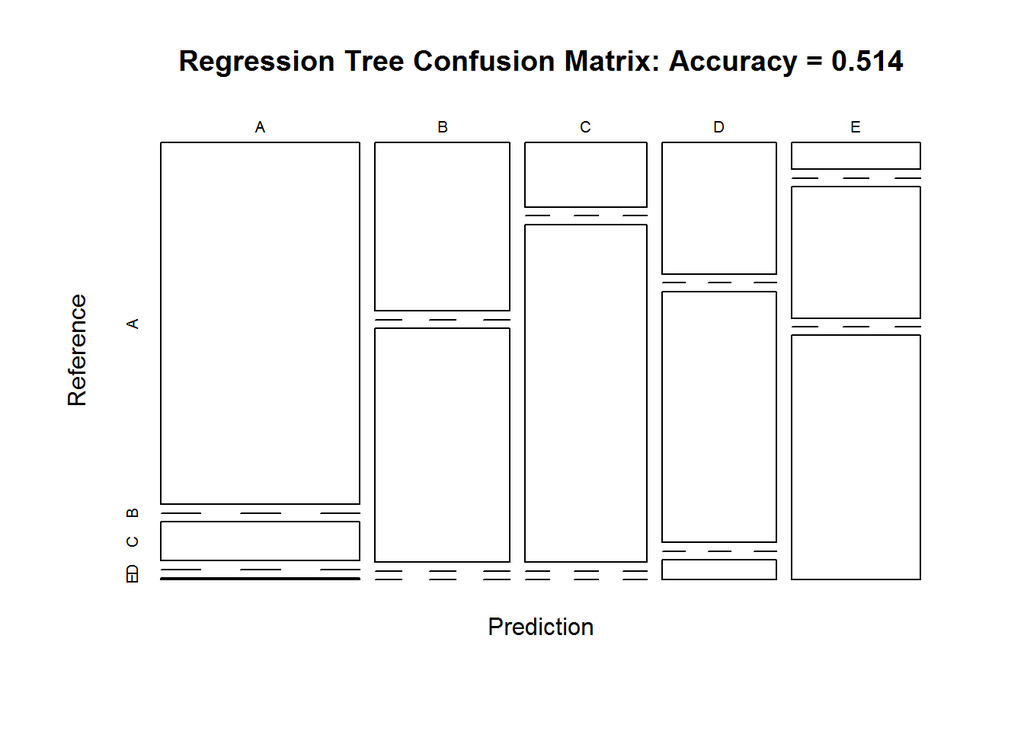

```r
plot(result1$table, col = result1$byClass,
     main = paste("Regression Tree Confusion Matrix: Accuracy =",
                  round(result1$overall['Accuracy'], 4)))
```

The accuracies of the model using regression tree isn’t good at all. The accuracy is only around 50%, which is not acceptable.

# Random Forest

```r
# try full model
modelFit2 <- randomForest(classe ~., data=subTraining)
result2<- confusionMatrix(subTesting$classe, predict(modelFit2, newdata=subTesting))

result2
```

```
## Confusion Matrix and Statistics
##
##           Reference
## Prediction    A    B    C    D    E
##          A 2232    0    0    0    0
##          B    3 1513    2    0    0
##          C    0    4 1364    0    0
##          D    0    0   14 1270    2
##          E    0    0    0    3 1439
##
## Overall Statistics
##
##                Accuracy : 0.9964
##                  95% CI : (0.9948, 0.9976)
##     No Information Rate : 0.2849
##     P-Value [Acc > NIR] : < 2.2e-16
##
##                   Kappa : 0.9955
##  Mcnemar's Test P-Value : NA
##
## Statistics by Class:
##
##                      Class: A Class: B Class: C Class: D Class: E
## Sensitivity            0.9987   0.9974   0.9884   0.9976   0.9986
## Specificity            1.0000   0.9992   0.9994   0.9976   0.9995
## Pos Pred Value         1.0000   0.9967   0.9971   0.9876   0.9979
## Neg Pred Value         0.9995   0.9994   0.9975   0.9995   0.9997
## Prevalence             0.2849   0.1933   0.1759   0.1622   0.1837
## Detection Rate         0.2845   0.1928   0.1738   0.1619   0.1834
## Detection Prevalence   0.2845   0.1935   0.1744   0.1639   0.1838
## Balanced Accuracy      0.9993   0.9983   0.9939   0.9976   0.9991
```

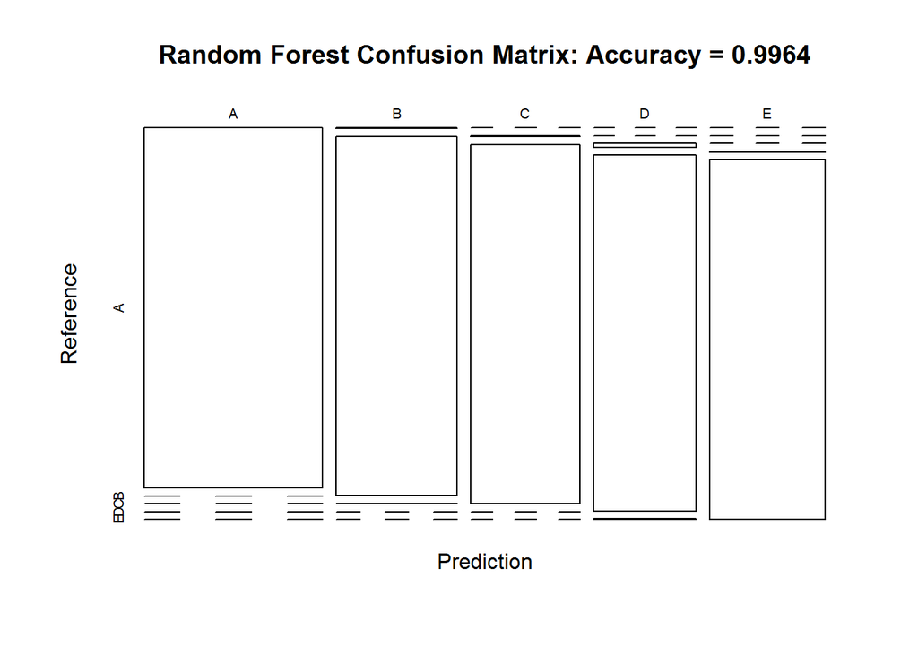

```r
plot(result2$table, col = result2$byClass,
     main = paste("Random Forest Confusion Matrix: Accuracy =",
                  round(result2$overall['Accuracy'], 4)))
```

The model with random forest model has a accuracy of 0.996, which is even better.

# Generalized Boosted Regression

```r
modelFit3 <- train(classe ~ ., data=subTraining, method = "gbm",
                 trControl = trainControl(method = "repeatedcv",
                           number = 5,
                           repeats = 1),
                 verbose = FALSE)
result3 <- confusionMatrix(subTesting$classe, predict(modelFit3, newdata = subTesting))
result3
```

```
## Confusion Matrix and Statistics
##
##           Reference
## Prediction    A    B    C    D    E
##          A 2229    2    0    0    1
##          B   14 1484   17    3    0
##          C    0   10 1357    1    0
##          D    1    7   26 1252    0
##          E    0    7    3   21 1411
##
## Overall Statistics
##
##                Accuracy : 0.9856
##                  95% CI : (0.9827, 0.9881)
##     No Information Rate : 0.286
##     P-Value [Acc > NIR] : < 2.2e-16
##
##                   Kappa : 0.9818
##  Mcnemar's Test P-Value : NA
##
## Statistics by Class:
##
##                      Class: A Class: B Class: C Class: D Class: E
## Sensitivity            0.9933   0.9828   0.9672   0.9804   0.9993
## Specificity            0.9995   0.9946   0.9983   0.9948   0.9952
## Pos Pred Value         0.9987   0.9776   0.9920   0.9736   0.9785
## Neg Pred Value         0.9973   0.9959   0.9929   0.9962   0.9998
## Prevalence             0.2860   0.1925   0.1788   0.1628   0.1800
## Detection Rate         0.2841   0.1891   0.1730   0.1596   0.1798
## Detection Prevalence   0.2845   0.1935   0.1744   0.1639   0.1838
## Balanced Accuracy      0.9964   0.9887   0.9828   0.9876   0.9972
```

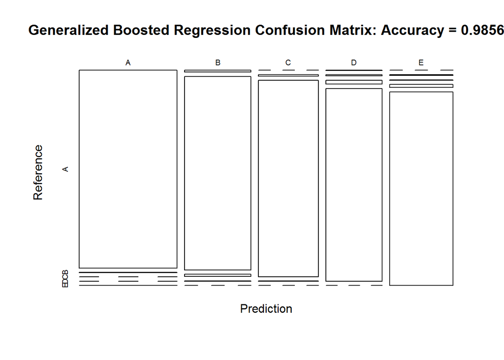

```r
plot(result3$table, col = result3$byClass,
     main = paste("Generalized Boosted Regression Confusion Matrix: Accuracy =",
                  round(result3$overall['Accuracy'], 4)))
```

# Croos Validation

```r
x = 10
parts <- split(subTraining, f = rep_len(1:x, nrow(subTraining)))

# make a help function to combine the list of 10 equal size data
combinedata <- function(index){
  data <- parts[[index[1]]]
  for (i in 2:(length(index))) data <- rbind(data, parts[[index[i]]])
  data
}

cross.validation.result <- as.data.frame(matrix(nrow=7, ncol=x))

index <- 1:x

for (i in 1:x){
  currentdata <- combinedata(index[index!= i])
  model <- randomForest(classe~., data=currentdata)
  result <- confusionMatrix(parts[[i]]$classe, predict(model, newdata=parts[[i]]))
  cross.validation.result[,i] <- result$overall
}
cross.validation.result
```

```
##          V1        V2        V3        V4        V5        V6        V7
## 1 0.9957555 0.9974533 0.9974533 0.9966044 0.9966044 0.9966044 0.9983008
## 2 0.9946315 0.9967792 0.9967788 0.9957046 0.9957045 0.9957047 0.9978506
## 3 0.9901228 0.9925757 0.9925757 0.9913290 0.9913290 0.9913290 0.9938754
## 4 0.9986204 0.9994745 0.9994745 0.9990741 0.9990741 0.9990741 0.9997941
## 5 0.2843803 0.2835314 0.2843803 0.2852292 0.2852292 0.2852292 0.2846219
## 6 0.0000000 0.0000000 0.0000000 0.0000000 0.0000000 0.0000000 0.0000000
## 7       NaN       NaN       NaN       NaN       NaN       NaN       NaN
##          V8        V9       V10
## 1 0.9983008 0.9966015 0.9949023
## 2 0.9978506 0.9957016 0.9935539
## 3 0.9938754 0.9913216 0.9889377
## 4 0.9997941 0.9990733 0.9981270
## 5 0.2846219 0.2846219 0.2829227
## 6 0.0000000 0.0000000 0.0000000
## 7       NaN       NaN       NaN
```

For the purpose of prediction, the model with higher accuracy was selected which is random forest. Because of we should use the model with highest accuracy.

## Conclusion

Without comparing the out of sample error rates, we can simply tell the Random forest classification technique works better than a regression tree and a generalized boosted regression in this case.